# Breast Cancer Survival

# Breast Cancer Survival Prediction with Machine Learning

Survival analysis of 1,829 breast cancer patients from the METABRIC cohort, comparing classical Cox regression against modern ML survival models and interpreting predictions with SHAP.

## Question

Can machine learning survival models outperform Cox regression for predicting breast cancer mortality, and which clinical features drive those predictions?

## Data

METABRIC (Molecular Taxonomy of Breast Cancer International Consortium) — 1,829 patients, 1,064 events (58% event rate), follow-up to ~350 months. Accessed via [cBioPortal](https://www.cbioportal.org/).

## Methods

Three models were compared under 5-fold cross-validation: - **Cox Proportional Hazards** — classical baseline - **Accelerated Oblique Random Survival Forest (AORSF)** — tree-based ML, no PH assumption - **Conditional Inference Survival Forest (Partykit)** — non-parametric tree ensemble

Model discrimination was evaluated using the concordance index (C-index). The proportional hazards assumption was tested via Schoenfeld residuals and found to be violated for most covariates (global p < 2e-16), motivating the ML approaches.

SHAP values from a gradient boosting classifier were used to interpret feature contributions at the individual and population level.

## Results

| Model | C-index (5-fold CV) |
| --- | --- |
| Cox | 0.662 |
| AORSF | 0.671 |
| Partykit RSF | 0.677 |

Both ML models outperform Cox. Age at diagnosis, lymph node involvement, and the Nottingham Prognostic Index (NPI) are the strongest predictors across all models.

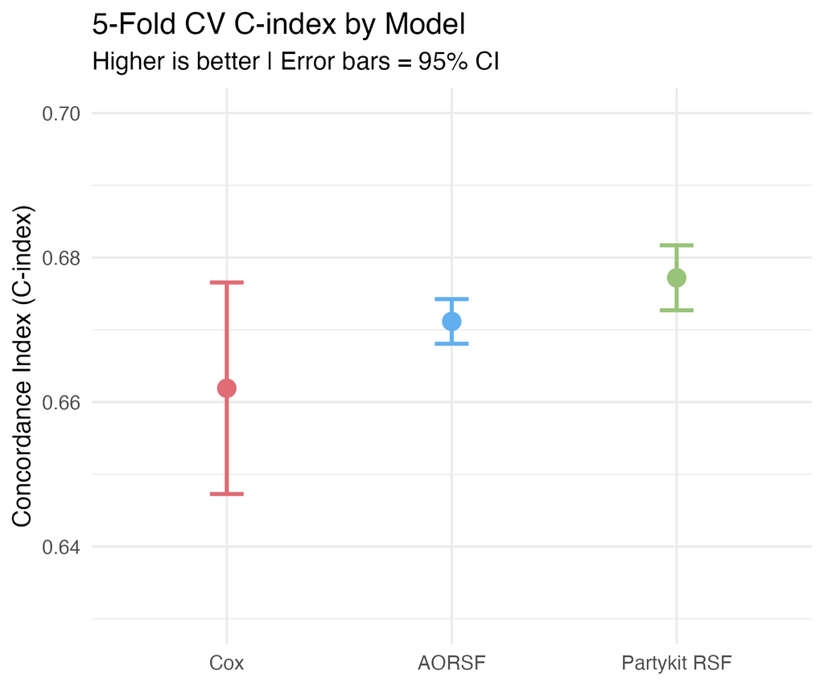

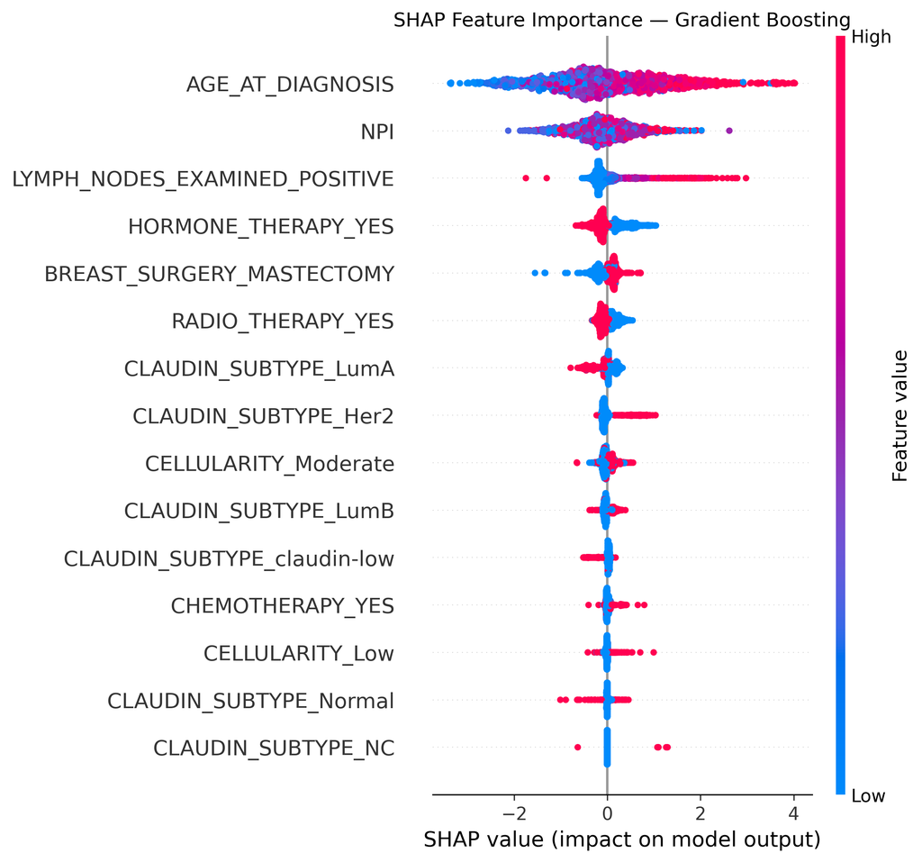